# Using R for Multilevel Modelling (II)

Guanpeng DONG

21 January 2017

## Learning Objectives

- Implement Random Slope Multilevel Models in R
- Analyse the ML model estimation results in R

## Implementing MLM in R

This tutorial will show how to use the `lme4` Package (short for linear mixed effect models) in R to fit random slope MLM and use the companion `merTools` Package to neatly analyse the model output from `lme4`. This tutorial will cover getting set up and running a few random slope multilevel models and interpret model estiamtion results.

We continue to use the census data in Liverpool to conduct an in-depth analysis on the health inequality. The aim is to build a multiple-scale spatial model to explain health inequality and identify spatially varying relationships between health status and other socioeconomic factors in Liverpool.

```r
#setwd("/Users/gavin/Dropbox/Teaching/ENVS453 Spatial Analysis/Lecture 2/Practical")

library(rgdal)
```

```r
library(maptools)
library(classInt)
library(RColorBrewer)
library(lme4)
library(merTools)
library(ggplot2)
```

Import the OA spatial data

```r
OA <- readOGR(dsn = ".", layer = "OA", stringsAsFactors = FALSE)
head(OA@data)
```

```
##       OA_CD   LSOA_CD   MSOA_CD    LAD_CD pop H_Vbad H_bad H_fair H_good
## 0 E00176737 E01033761 E02006932 E08000012 185      1     2      9     53
## 1 E00033515 E01006614 E02001358 E08000012 281      2    20     47    111
## 2 E00033141 E01006546 E02001365 E08000012 208      3    10     22     71
## 3 E00176757 E01006646 E02001369 E08000012 200      7     8     17     52
## 4 E00034050 E01006712 E02001375 E08000012 321      4    10     32    112
## 5 E00034280 E01006761 E02001366 E08000012 187      4    25     70     57
##   H_Vgood  age_men age_med     age_60     S_Rent     Ethnic illness
## 0     120 27.94054      25 0.01081081 0.05263158 0.35135135     185
## 1     101 37.71174      36 0.16370107 0.17600000 0.04626335     281
## 2     102 37.08173      32 0.19711538 0.02352941 0.01923077     208
## 3     116 33.73000      29 0.10000000 0.22222222 0.21500000     200
## 4     163 34.19003      34 0.14018692 0.02222222 0.07788162     321
## 5      31 56.09091      53 0.44919786 0.88524590 0.11764706     187
##        unemp males   dis_ind
## 0 0.04379562   122 0.1835524
## 1 0.12101911   128 0.1966401
## 2 0.11214953    95 0.2588795
## 3 0.03597122   120 0.2867488
## 4 0.07428571   158 0.1942604
## 5 0.44615385   123 0.2752206
```

We will only need the data slot of the spatial data OA to run models, so we extract the attribute data (variables) from the OA and name it `OAdata`.

```r
OAdata <- OA@data

## To see the hierarchical data structure clearly, we sort the data by the MSOA code "MSOA_CD". Note, here we implicitly assume we have a two-level data structure with OAs nesting into MSOAs.
# Sort a dataframe based on a column by using the `order` function from base R
OAdata <- OAdata[order(OAdata$MSOA_CD),]
head(OAdata)
```

```
##         OA_CD   LSOA_CD   MSOA_CD    LAD_CD pop H_Vbad H_bad H_fair H_good
## 36  E00033721 E01006651 E02001347 E08000012 312      2    10     25     90
## 61  E00033712 E01006660 E02001347 E08000012 360     14    17     46     95
## 112 E00033717 E01006660 E02001347 E08000012 239     11    13     26     64
## 180 E00033727 E01006653 E02001347 E08000012 305     23    30     44     92
## 225 E00033711 E01006658 E02001347 E08000012 124      9    16     27     34
## 228 E00033703 E01006660 E02001347 E08000012 276     13    46     69     69
##     H_Vgood  age_men age_med     age_60     S_Rent     Ethnic illness
## 36      185 33.86859    39.0 0.07371795 0.01769912 0.03846154     312
## 61      188 38.58889    40.0 0.18055556 0.14516129 0.12500000     360
## 112     125 33.27197    36.0 0.09205021 0.27184466 0.12552301     239
## 180     116 39.41967    40.0 0.22950820 0.46376812 0.02950820     305
## 225      38 41.35484    41.5 0.28225806 0.61428571 0.04032258     124
## 228      79 50.63768    54.0 0.43115942 0.67664671 0.09420290     276
##          unemp males   dis_ind
## 36  0.03723404   148 0.2342084
## 61  0.09090909   180 0.2342084
## 112 0.08130081   113 0.2342084
## 180 0.14285714   132 0.2342084
## 225 0.12195122    64 0.2342084
## 228 0.13483146   134 0.2342084
```

### An initial investigation of varying relationships between health status and other variables

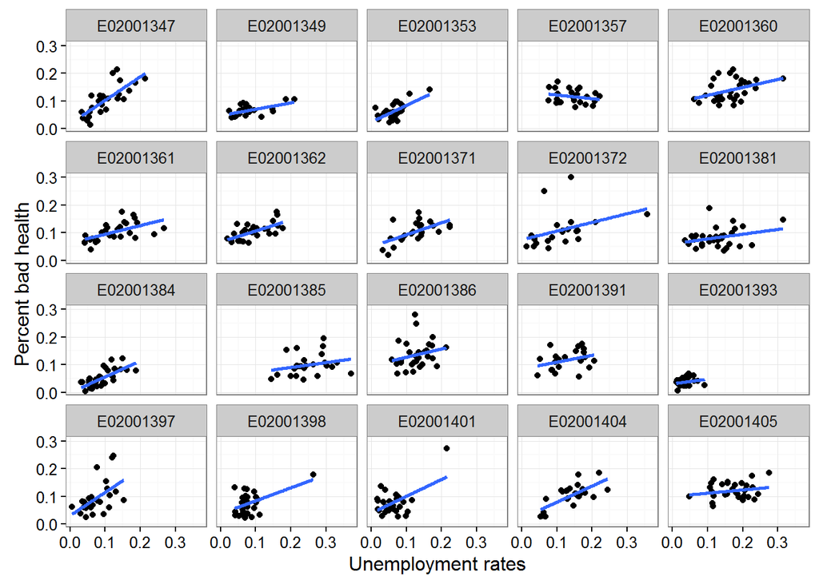

```r
## Create a variable presenting the proportions of people who reported bad health status by combining categories of Very Bad and Bad health statuses.
OAdata$H_bad_Prop <- (OAdata$H_Vbad + OAdata$H_bad) / OAdata$pop

# random select 20 MSOAs to show the relationship between reported health status and unemployment rates
sample.20 <- sample(unique(OAdata$MSOA_CD), 20, replace = FALSE)

ggplot(OAdata[OAdata$MSOA_CD %in% sample.20,], aes(x = unemp, y = H_bad_Prop)) + geom_point() +
  geom_smooth(method = "lm", se = FALSE) +
  facet_wrap(~ MSOA_CD) +
  xlab("Unemployment rates") +
  ylab("Percent bad health") +
  theme_bw()
```

In this replication, the graph shows great variability of the associations between health status and unemployment rates across MSOAs, ranging from negative to positive associations. This provides motivation for us to use a random slope MLM.

### Specifying and estimating a random slope MLM

Again, we use the `lmer` function to estimate random slope MLM using a special syntax: `(1 + unemp |MSOA_CD)`, which tells `lmer` to fit a random slope multilevel model. That is, both the model intercept terms and the effect of unemployment rates on reported health status vary across MSOAs.

The model specification is reiterated here with $i$ indexing OA units and $j$ MSOA units.

**The OA level (or Micro-level) model is**,
$$H\_bad\_Prop_{i,j} = \beta_{0,j} + \beta_1*age\_60_{i,j} + \beta_2*S\_Rent_{i,j} + \beta_{3,j}*unemp_{i,j} + \epsilon_{i,j}$$

**The MSOA level (or Macro-level) model is**,
$$\begin{aligned}
\beta_{0,j} &= \beta_{0} + \mu_{0,j} \\
\beta_{3,j} &= \beta_{3} + \mu_{3,j}
\end{aligned}$$

which gives the **combined model**,
$$H\_bad\_Prop_{i,j} = \beta_{0} + \beta_1*age\_60_{i,j} + \beta_2*S\_Rent_{i,j} + \beta_3*unemp_{i,j} + \mu_{0,j} + \mu_{3,j}*unemp_{i,j} + \epsilon_{i,j}$$

```r
model.0 <- lmer(H_bad_Prop ~ age_60 + S_Rent + unemp + (1 + unemp|MSOA_CD), data = OAdata)
summary(model.0)
```

```
## Linear mixed model fit by REML ['lmerMod']
## Formula: H_bad_Prop ~ age_60 + S_Rent + unemp + (1 + unemp | MSOA_CD)
##    Data: OAdata
##
## REML criterion at convergence: -7213.5
##
## Scaled residuals:
##     Min      1Q  Median      3Q     Max
## -3.3931 -0.6161 -0.0208  0.5588  5.9517
##
## Random effects:
##  Groups   Name        Variance  Std.Dev. Corr
##  MSOA_CD  (Intercept) 0.0004342 0.02084
##           unemp       0.0131613 0.11472  -0.91
##  Residual             0.0005433 0.02331
## Number of obs: 1584, groups:  MSOA_CD, 61
##
## Fixed effects:
##             Estimate Std. Error t value
## (Intercept) 0.005531   0.003313    1.67
## age_60      0.240530   0.007366   32.65
## S_Rent      0.091628   0.004041   22.67
## unemp       0.136198   0.020265    6.72
##
## Correlation of Fixed Effects:
##        (Intr) age_60 S_Rent
## age_60 -0.429
## S_Rent  0.103 -0.305
## unemp  -0.750  0.121 -0.451
```

**Task**

- Interpret the regression coefficients
- Get the covariance or correlation matrix between the random intercepts and random slopes of unemployment rates

Visualise the group-level random effects including the random intercept term and the randomn slopes.

First, extract the random effect estimates,

```r
MSOA_re <- REsim(model.0)
MSOA_re
```

```
##     groupFctr   groupID        term          mean        median         sd
## 1     MSOA_CD E02001347 (Intercept) -0.0033079651  2.286556e-03 0.08680919
## 2     MSOA_CD E02001348 (Intercept)  0.0016589543  2.807807e-03 0.09667182
## 3     MSOA_CD E02001349 (Intercept)  0.0017272751 -9.680676e-04 0.09364644
## 4     MSOA_CD E02001350 (Intercept)  0.0124910527  1.929103e-02 0.06868843
## 5     MSOA_CD E02001351 (Intercept)  0.0219170965  2.059210e-02 0.06175540
## 6     MSOA_CD E02001352 (Intercept)  0.0172013674  1.792243e-02 0.07554122
## 7     MSOA_CD E02001353 (Intercept)  0.0012043942 -4.481688e-03 0.09494575
## 8     MSOA_CD E02001354 (Intercept) -0.0004921177  2.690090e-03 0.05115396
## 9     MSOA_CD E02001355 (Intercept)  0.0045970793  7.517415e-03 0.05892248
## 10    MSOA_CD E02001356 (Intercept)  0.0295356046  2.668817e-02 0.05392014
## 11    MSOA_CD E02001357 (Intercept)  0.0219953785  2.016730e-02 0.06853375
## 12    MSOA_CD E02001358 (Intercept)  0.0056265091  9.563226e-03 0.05631410
## 13    MSOA_CD E02001359 (Intercept) -0.0067956774 -8.668429e-03 0.08567874
## 14    MSOA_CD E02001360 (Intercept)  0.0192619287  1.785030e-02 0.05425405
```

[output cut: 108 more lines]

```r
str(MSOA_re)
```

```
## 'data.frame':    122 obs. of  6 variables:
##  $ groupFctr: chr  "MSOA_CD" "MSOA_CD" "MSOA_CD" "MSOA_CD" ...
##  $ groupID  : chr  "E02001347" "E02001348" "E02001349" "E02001350" ...
##  $ term     : chr  "(Intercept)" "(Intercept)" "(Intercept)" "(Intercept)" ...
##  $ mean     : num  -0.00331 0.00166 0.00173 0.01249 0.02192 ...
##  $ median   : num  0.002287 0.002808 -0.000968 0.019291 0.020592 ...
##  $ sd       : num  0.0868 0.0967 0.0936 0.0687 0.0618 ...
```

Then, create a caterpillar graph to visualise the mean (or median) of each MSOA random effect and the associated 95% confidence interval.

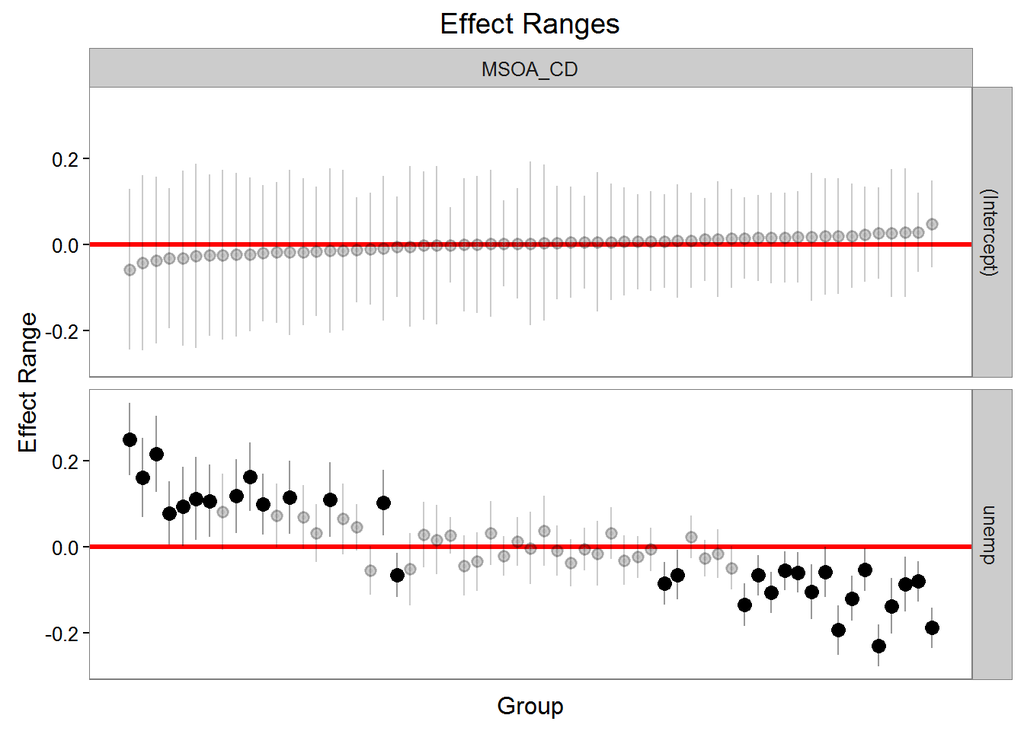

```r
p <- plotREsim(MSOA_re)
p
```

Looking at the graph, there are several very interesting findings worth mentioning. First, the random intercepts don’t seem to differentiate significantly with each other as their 95% confidence intervals overlap with each other. Second, the effects of unemployment on health status vary significantly across MSOAs: positive effects are observed in some MSOAs while negative effects in some MSOAS. Third, it seems that the significant differences in health status between MSOAs observed in the random intercept MLM might be due to the fact that the model doesn’t capture the spatially varying effects of unemployment on health.

Again, we can map these model-based random effect estimates by linking them to the MSOA shapefile using the `merge` function.

```r
## Import the MSOA spatial data
MSOA <- readOGR(dsn = ".", layer = "MSOA", stringsAsFactors = FALSE)
## We first create a new dataframe including random intercepts and slopes estimates from the MSOA_re object.
MSOA_code <- MSOA_re[MSOA_re$term == "(Intercept)","groupID"]
MSOA_intercept <- MSOA_re[MSOA_re$term == "(Intercept)","mean"]
MSOA_slope <- MSOA_re[MSOA_re$term == "unemp","mean"]
MSOA_link <- data.frame(MSOA_code, MSOA_intercept, MSOA_slope)
MSOA_link$MSOA_code <- as.character(MSOA_link$MSOA_code )
str(MSOA_link)
```

```
## 'data.frame':    61 obs. of  3 variables:
##  $ MSOA_code     : chr  "E02001347" "E02001348" "E02001349" "E02001350" ...
##  $ MSOA_intercept: num  -0.00331 0.00166 0.00173 0.01249 0.02192 ...
##  $ MSOA_slope    : num  0.03382 -0.00136 0.01754 -0.05554 -0.11993 ...
```

```r
MSOA@data <- merge(MSOA@data, MSOA_link, by.x = "MSOA_CD", by.y = "MSOA_code", all.x = TRUE)
head(MSOA@data)
```

```
##     MSOA_CD    LAD_CD  pop H_Vbad H_bad H_fair H_good H_Vgood  age_men
## 1 E02001347 E08000012 7653    188   567   1003   2258    3637 37.93258
## 2 E02001348 E08000012 7222    146   402    982   2316    3376 37.92855
## 3 E02001349 E08000012 7966    114   410   1108   2478    3856 38.09151
## 4 E02001350 E08000012 7856    229   649   1191   2285    3502 38.67426
## 5 E02001351 E08000012 8894    219   765   1451   2744    3715 37.53497
## 6 E02001352 E08000012 7416    152   570   1222   2348    3124 36.87163
##   age_med    age_60     S_Rent     Ethnic illness      unemp males
## 1      38 0.1903829 0.28714107 0.08545668    7653 0.09336870  3655
## 2      37 0.1962060 0.05781449 0.04403212    7222 0.08500652  3526
## 3      38 0.1827768 0.06604325 0.04644740    7966 0.07864665  3982
## 4      38 0.2115580 0.39332748 0.09101324    7856 0.11673699  3661
## 5      36 0.1821453 0.42987198 0.07499438    8894 0.13531353  4580
## 6      35 0.1635653 0.30334865 0.08994067    7416 0.13540479  4206
##     dis_ind MSOA_intercept   MSOA_slope
## 1 0.2342084   -0.003307965  0.033820957
## 2 0.2203198    0.001658954 -0.001363989
## 3 0.2680301    0.001727275  0.017543403
## 4 0.2223367    0.012491053 -0.055537526
## 5 0.2027585    0.021917096 -0.119933567
## 6 0.2796783    0.017201367 -0.104974764
```

Then, use the `spplot` function to map the random effect estimates.  
**The pattern of random intercepts at the MSOA scale**:

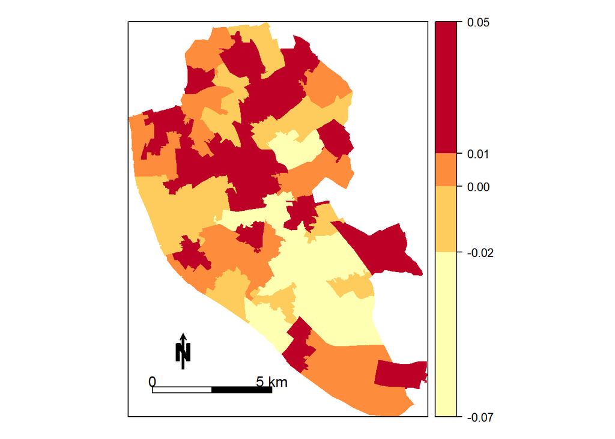

```r
temp <- MSOA@data$MSOA_intercept
brks.temp <- classIntervals(temp, n = 5, style = "quantile")
brks.temp <- round(brks.temp$brks, digits = 2)
brks.temp[1] <- brks.temp[1] - 0.01
brks.temp[5 + 1] <- brks.temp[5 + 1] + 0.01

# Scale bar and legend
xx <- MSOA@bbox

scalebar <- list("SpatialPolygonsRescale", layout.scale.bar(),
            offset = c(min(xx[1,] + 1000),xx[2,1] + 1000), scale = 5000,    fill=c("transparent","black"))

text1 <- list("sp.text", c(min(xx[1,]) + 1000,xx[2,1] + 1500), "0")
text2 <- list("sp.text", c(min(xx[1,]) + 6000,xx[2,1] + 1500), "5 km")
northarrow <- list("SpatialPolygonsRescale", layout.north.arrow(),
                     offset = c(min(xx[1,]) + 2000,xx[2,1] + 2000), scale = 1500)

## Plot
spplot(MSOA, "MSOA_intercept", sp.layout=list(scalebar,text1,text2,northarrow),
        at = brks.temp, col.regions = brewer.pal(5, "YlOrRd"),
        col="transparent",pretty=TRUE,
        colorkey=list(labels=list(at=brks.temp)))
```

Then, use the `spplot` function to map the random effect estimates.  
**The pattern of random slopes at the MSOA scale**:

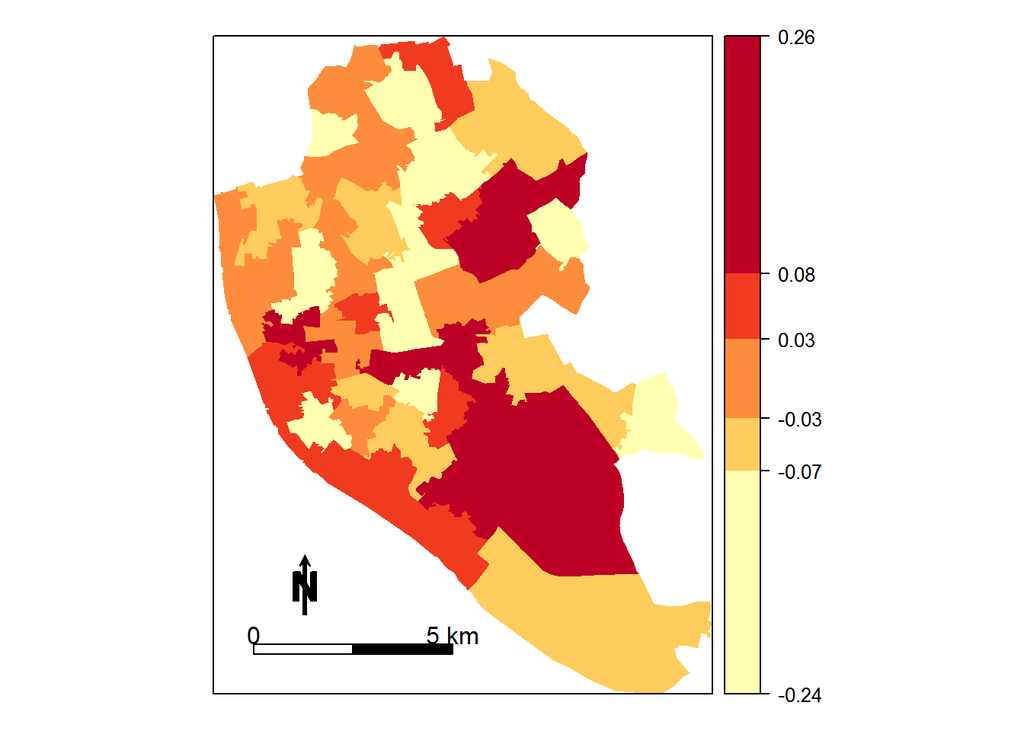

```r
temp <- MSOA@data$MSOA_slope
brks.temp <- classIntervals(temp, n = 5, style = "quantile")
brks.temp <- round(brks.temp$brks, digits = 2)
brks.temp[1] <- brks.temp[1] - 0.01
brks.temp[5 + 1] <- brks.temp[5 + 1] + 0.01

# Scale bar and legend
xx <- MSOA@bbox

scalebar <- list("SpatialPolygonsRescale", layout.scale.bar(),
            offset = c(min(xx[1,] + 1000),xx[2,1] + 1000), scale = 5000,    fill=c("transparent","black"))

text1 <- list("sp.text", c(min(xx[1,]) + 1000,xx[2,1] + 1500), "0")
text2 <- list("sp.text", c(min(xx[1,]) + 6000,xx[2,1] + 1500), "5 km")
northarrow <- list("SpatialPolygonsRescale", layout.north.arrow(),
                     offset = c(min(xx[1,]) + 2000,xx[2,1] + 2000), scale = 1500)

## Plot
spplot(MSOA, "MSOA_slope", sp.layout=list(scalebar,text1,text2,northarrow),
        at = brks.temp, col.regions = brewer.pal(5, "YlOrRd"),
        col="transparent",pretty=TRUE,
        colorkey=list(labels=list(at=brks.temp)))
```

**Task**

- Can you make sense of the spatial patterns?
- Explore whether the relatonships between health status and other predictor variables vary significantly across MSOAs